# Exercise: Introduction to the Bayesian Framework

Likelihoods and Priors

Author

Alexander Massey

Published

April 6, 2026

## 1 Background

This exercise builds intuition for the three ingredients of Bayesian inference:

1. **The likelihood** — how probable is the data under different parameter values?
2. **The prior** — what do we believe before seeing the data?
3. **The posterior** — how do we update our beliefs after seeing the data?

We focus on the first two components here. A recurring theme is that choices which seem innocuous — a flat prior, an arbitrary starting value — can have substantial and sometimes surprising consequences.

## 2 Part 1: Maximum Likelihood Estimation

Before placing priors, it helps to understand what the likelihood surface looks like on its own. The **maximum likelihood estimate (MLE)** is the parameter value that makes the observed data most probable under the assumed model. In simple cases it has a closed form; in general, we find it numerically.

### 2.1 The Binomial likelihood: bird breeding

A field ecologist observes **3 successful breeding attempts out of 10** tries ($k = 3$, $N = 10$). We model the number of successes as $k \sim \text{Binomial}(N, p)$ and want to estimate the breeding success probability $p$.

The log-likelihood is:

$$\ell(p) = \log \binom{N}{k} + k \log p + (N - k) \log(1 - p)$$

The MLE is analytically $\hat{p} = k/N = 0.3$, but we will find it numerically using `optim()`.

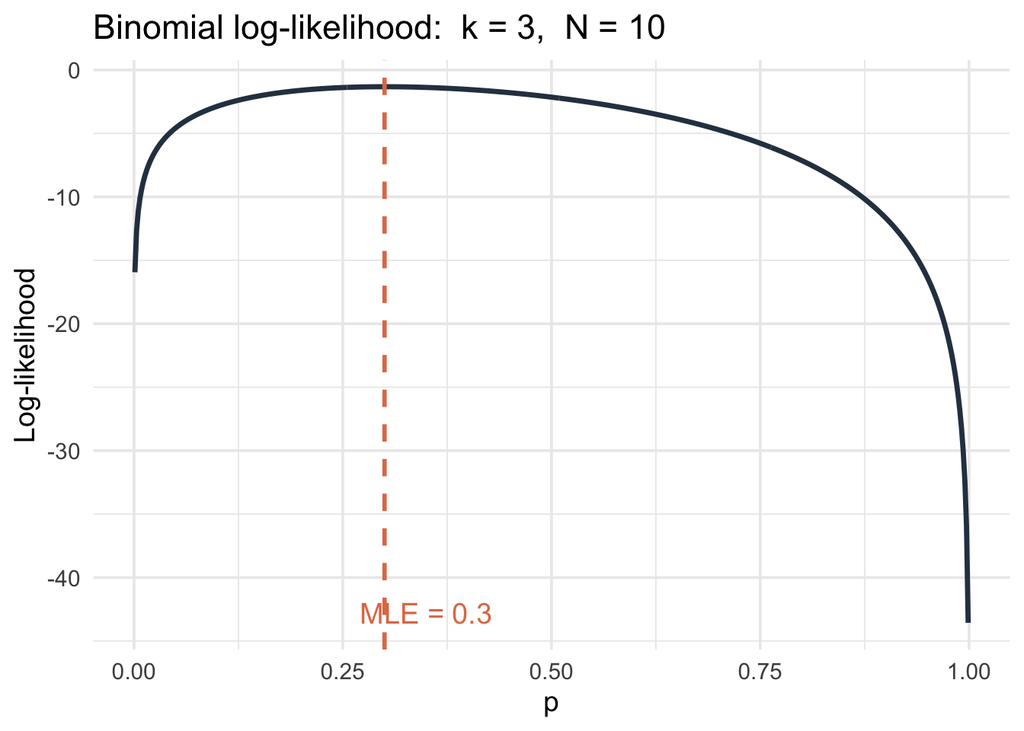

```r
library(ggplot2)

# Log-likelihood for Binomial(N = 10, p) with k = 3 successes
loglik <- function(p, k = 3, N = 10) {
  dbinom(x = k, size = N, prob = p, log = TRUE)
}

# Numerical MLE via optim() — minimise the NEGATIVE log-likelihood
fit <- optim(
  par    = 0.5,
  fn     = function(p) -loglik(p),
  method = "Brent",          # 1-D bounded optimiser
  lower  = 1e-6,
  upper  = 1 - 1e-6
)
mle <- fit$par

# Plot the log-likelihood surface
p_grid <- seq(0.001, 0.999, length.out = 500)
df <- data.frame(p = p_grid, ll = sapply(p_grid, loglik))

ggplot(df, aes(p, ll)) +
  geom_line(colour = "#2c3e50", linewidth = 1.2) +
  geom_vline(xintercept = mle, colour = "#e07b54",
             linewidth = 1, linetype = "dashed") +
  annotate("text", x = mle + 0.05, y = min(df$ll) + 0.8,
           label = paste0("MLE = ", round(mle, 3)),
           colour = "#e07b54", size = 5) +
  labs(x = "p", y = "Log-likelihood",
       title = "Binomial log-likelihood:  k = 3,  N = 10") +
  theme_minimal(base_size = 14)
```

**Questions:**

1. Change the data to $k = 0$ successes. What is the MLE? Plot the log-likelihood. What does this imply about using the MLE as a point estimate in small samples with extreme outcomes — and how does a Bayesian prior help?
2. The log-likelihood is quite flat over a wide range of $p$. What does this tell you about the **information content** of $N = 10$ observations? What happens if we increase $N$ to 100 (keeping $\hat{p} = 0.3$, so $k = 30$) and replot. How does the surface change?

**TipHint 1a — Zero successes**

```r
loglik_0 <- function(p) dbinom(x = 0, size = 10, prob = p, log = TRUE)
fit_0 <- optim(par = 0.5, fn = function(p) -loglik_0(p),
               method = "Brent", lower = 1e-6, upper = 1 - 1e-6)
fit_0$par   # → near 0
```

The MLE is $\hat{p} = 0$ — the model assigns zero probability to ever observing a success. A Beta(1,1) or weakly informative prior immediately regularises this toward the interior of $[0,1]$.

**TipHint 1b — Larger sample**

```r
loglik_large <- function(p) dbinom(x = 30, size = 100, prob = p, log = T)
loglik_small <- function(p) dbinom(x = 3, size = 10, prob = p, log = T)
p_grid <- seq(0.001, 0.999, length.out = 500)
df_large <- data.frame(p = p_grid, ll = sapply(p_grid, loglik_large))
df_small <- data.frame(p = p_grid, ll = sapply(p_grid, loglik_small))
ggplot(df_large, aes(p, ll)) + geom_line(color = "blue") +
 geom_line(data = df_small, color = "red") + theme_minimal()
```

The surface becomes much sharper (more peaked) around 0.3 — the data are more informative, leaving less posterior uncertainty regardless of the prior.

### 2.2 MLE for a Normal distribution

We now work with a two-parameter model. Suppose we have collected heights (in cm) from 100 individuals. We assume $\text{height}_i \sim \mathcal{N}(\mu, \sigma^2)$ and want to find the MLEs of $\mu$ and $\sigma$ numerically.

The log-likelihood is:

$$\ell(\mu, \sigma) = -\frac{n}{2}\log(2\pi\sigma^2) - \frac{1}{2\sigma^2}\sum_{i=1}^n (x_i - \mu)^2$$

The MLEs are analytically $\hat{\mu} = \bar{x}$ and $\hat{\sigma} = \sqrt{\frac{1}{n}\sum(x_i - \bar{x})^2}$, but `optim()` finds them in the same framework we will use for models without closed forms.

```r
set.seed(2020)
n      <- 100
height <- rnorm(n, mean = 170, sd = 10)

# Negative log-likelihood for Normal(mu, sigma)
negloglik <- function(theta, data) {
  mu    <- theta[1]
  sigma <- theta[2]
  -sum(dnorm(data, mean = mu, sd = sigma, log = TRUE))
}

# Check at an arbitrary starting point
negloglik(theta = c(150, 1), height)
```

```
[1] 28530.45
```

```r
# Optimise jointly over (mu, sigma)
fit <- optim(
  par = c(mean(height), sd(height)),   # sensible starting values
  fn  = negloglik,
  data = height
)
fit$par   # should recover ~ (170, 10)
```

```
[1] 171.09139  11.13706
```

**Questions:**

1. Run `optim()` with the deliberately bad starting values `par = c(150, 1)`. Does it still converge to the correct MLEs? Now try `par = c(0, 0.001)`. What goes wrong, and why?
2. Compare `fit$par` to `c(mean(height), sd(height))`. Are they identical? The MLE for $\sigma$ is the *biased* population standard deviation $\hat{\sigma} = \sqrt{\frac{1}{n}\sum(x_i - \bar{x})^2}$, not R’s `sd()` which uses $n-1$. Is the difference meaningful here at $n = 100$?

**TipHint 2a — Bad starting values**

`sigma = 0.001` causes `dnorm()` to return `-Inf` for most observations (essentially assigning zero density to data far from the mean). `optim()` cannot compute a gradient and fails. This illustrates that numerical optimisers are sensitive to the scale of the parameter space — a practical reason to work on the log scale for variance parameters.

**TipHint 2b**

The MLE is consistent but not guaranteed to be unbiased. Using $n-1$ corrects this bias so it should be larger.

## 3 Part 2: The Pitfalls of Flat Priors

A **flat (uniform) prior** over a parameter expresses “complete ignorance” — every value is equally plausible before seeing data. This sounds reasonable but causes two related problems:

1. **It is not invariant to reparameterisation.** A flat prior on $p$ is *not* flat on $\log(p/(1-p))$ — the model “knows” more than we think it does.
2. **It might place substantial mass in implausible regions**, especially on unbounded or transformed scales.

### 3.1 Flat priors on a probability scale

Consider the logistic regression model for binary survival $\phi_i$:

$$\text{logit}(\phi_i) = \beta_0 + \beta_1 x_i, \qquad \beta_0, \beta_1 \sim \mathcal{N}(0, \tau^2)$$

The prior on $\phi_i = \text{logit}^{-1}(\beta_0 + \beta_1 x_i)$ depends critically on $\tau$.

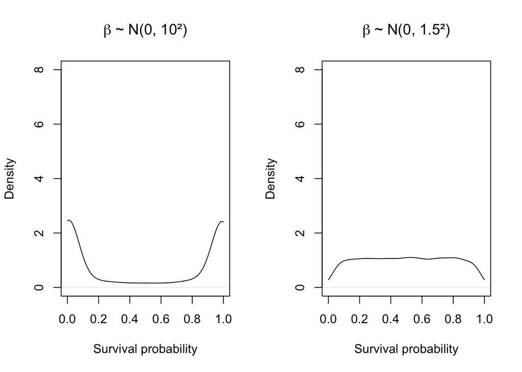

```r
set.seed(42)
n_sim <- 10000

# "Flat" prior on the logit scale — large variance
beta_flat <- rnorm(n_sim, 0, 10)
phi_flat  <- plogis(beta_flat)   # back-transform to probability scale

# Weakly informative prior
beta_weak <- rnorm(n_sim, 0, 1.5)
phi_weak  <- plogis(beta_weak)

par(mfrow = c(1, 2))
plot(density(phi_flat, from = 0, to = 1),
     main = expression(beta ~ "~ N(0, 10²)"),
     xlab = "Survival probability", ylim = c(0, 8))
plot(density(phi_weak, from = 0, to = 1),
     main = expression(beta ~ "~ N(0, 1.5²)"),
     xlab = "Survival probability", ylim = c(0, 8))
```

```r
par(mfrow = c(1, 1))
```

**Questions:**

1. Describe the shape of the implied prior on $\phi$ when $\beta \sim \mathcal{N}(0, 10^2)$. Is this really “non-informative”? What claim does this prior make?
2. How does the implied prior change with $\mathcal{N}(0, 1.5^2)$? Is this more or less informative in the logit space? Why is it *more appropriate* despite being “informative”?
3. Try $\tau = 0.5$ and $\tau = 5$. Describe the trade-off. Is there a value of $\tau$ you would defend for a survival probability in ecology?

**TipHint 3a**

$\mathcal{N}(0, 10^2)$ on the logit scale concentrates mass near 0 and 1 on the probability scale — it is actually *highly* informative, favouring extreme survival probabilities. This is the opposite of what “non-informative” should mean for a bounded probability.

**TipHint 3b**

$\mathcal{N}(0, 1.5^2)$ on the logit scale maps to an approximately uniform distribution on the probability scale — it is diffuse where it matters (on the constrained $[0,1]$ space) and avoids the pathological spike at the boundaries. Informativeness is always relative to the parameterisation.